# 00

### **00-01. DB info**

### **00-02. 입력값**

## 00-01. DB info

### `Population DB` : 성-연령구간 (이하 인구구간) 별 디지털 인구모수 DB (닐슨 코리안클릭 기준)

- `date` : 수집일
- `gender` : 성별
- `age_min` : 인구구간內 최소 연령
- `age_max` : 인구구간內 최대 연령
- `population` : 인구구간별 인구모수

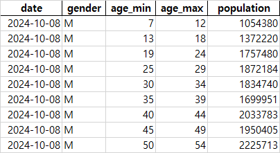

### `Distribution DB` : 매체-인구구간 별 MAU 분포 DB (닐슨 코리안클릭 기준)

- `date` : 수집일
- `platform` : 매체
- `gender` : 성별
- `age_min` : 인구구간 최소 연령
- `age_max` : 인구구간 최대 연령
- `distribution` : 매체의 전체 MAU 대비, 해당 매체-인구구간의 MAU의 비율

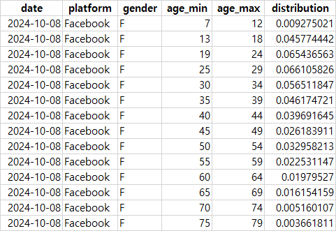

### `Parameter DB` : 매체-상품-인구구간 별 예측 모델 회귀계수

- `date` : 수집일
- `platform` : 매체
- `product` : 상품
  - `product` 컬럼 내 `subtotal`에 해당하는 행은 매체별 통합 도달률 계산만을 위한 모형
- `gender` : 성별
- `age_min` : 인구구간內 최소 연령
- `age_max` : 인구구간內 최대 연령
- `a`, `b`, `c` : 매체-상품-인구구간별 예측 모델 회귀계수
  - `c` : 매체-상품-인구구간별 도달커버리지 (최대 도달 한계)

$$Reach\;1+(\%)=\frac{c}{1 + exp(-(a + b \times \text{ln}(GRPs)))}$$

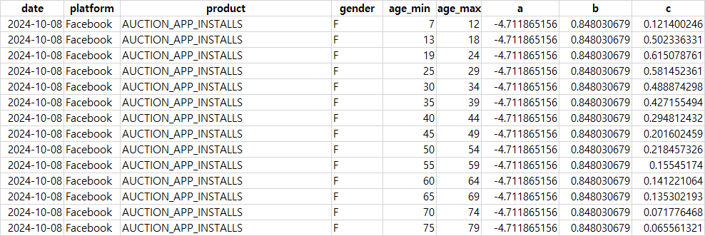

### `Parameter Nplus DB` : Reach N+ 예측 모델 회귀 계수

- `gender` : 성별
- `age_min` : 인구구간內 최소 연령
- `age_max` : 인구구간內 최대 연령
- `ratio_{N}_a`, `ratio_{N}_af`, `ratio_{N}_grps` : Reach `N`+(2+ ~ 10+) 예측을 위한 모델 회귀계수

$$Reach\;N+ (\%) = Reach\;1+(\%) \times \Pi^n_{i=2} ratio_{n+}$$$$ratio_{n+} = {1 \over {1\;+\;exp{(-({ratio_n+_{a}\;+\;ratio\_n+_{A.F}\;\times\;\text{ln}(A.F)\;+\;ratio\_n+_{grps}\;\times\;\text{ln}(GRPs}))}}}$$

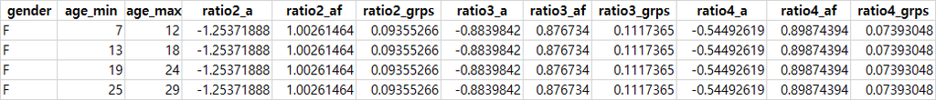

### 요약

DB_Diagram

[figure not shown]

## 00-02. 입력값

### 1. 분석 믹스 (`input_mix`) : 미디어믹스 형태의 테이블. 테이블의 행 단위로 정제

- `campaign` : 캠페인 명
- `platform` : 매체
  - `Parameter DB` 內 `platform`컬럼의 고유 목록 중 택 1
- `product` : 상품
  - `Parameter DB` 內 `product`컬럼의 고유 목록 중 `subtotal`을 제외하고 택 1
- `date_start` : 집행시작일. [YYYY-MM-DD]
- `date_end` : 집행종료일. [YYYY-MM-DD]
- `gender` : 데모타겟 성별. ['M', 'F', 'P'] 中 택 1
- `min` : 데모타겟 연령구간 內 최소연령 [7, 79] 범위 사이 정수
- `max` : 데모타겟 연령구간 內 최대연령 [7, 79] 범위 사이 정수
- `retargeting` : 리타겟팅 모수
- `impact` : 인지효과 가중치. [0%, 100%] 범위 內 입력
  - 미입력시 100%
- `budget` : 집행예산
- `bid_type` : 집행단가 유형
  - [`CPM`, `CPC`, `CPV`, `CPRP`, `E.IMP 직접입력`, `기집행 분석 (IMP)`, `기집행 분석 (GRP)`] 中 1 선택 (필수)
- `bid_cost` : 집행단가 (금액)
  - [`CPM`, `CPC`, `CPV`, CPRP`] 中 1일 때, 해당 단가 금액 입력 (필수)
  - [`E.IMP 직접입력`, `기집행 분석 (IMP)`, `기집행 분석 (GRP)`] 中 1일 때, 미입력
- `bid_rate` : 효율
  - `bid_cost`가 [`CPC`, `CPV'] 中 1일 때, 각각 CTR, VTR 입력 (필수)
  - 그 외의 경우 미입력
- `imp` : 노출량
  - `bid_cost`가 [`E.IMP 직접입력`, `기집행 분석 (IMP)`, `기집행 분석 (GRP)`] 中 1일 때, 각각 기대노출량, 기집행 노출량, 기집행 GRP 입력 (필수)
  - 그 외의 경우 미입력
- `reach` : 도달량
  - `bid_cost`가 [`기집행 분석 (IMP)`, `기집행 분석 (GRP)`] 中 1일 때, 각각 기집행 도달수, 기집행 도달률 입력 (필수)
  - 그 외의 경우 미입력

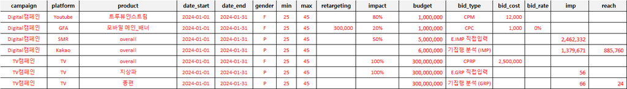

#### $\rightarrow$ 위의 조건에 부합하지 않는 모든 행들은 분석에서 제외

#### 정제

1. `min`
- 모든 행의 값에 대하여, `Population DB` 內 `age_min`의 고유 값 중 가장 근삿값으로 변환

```
만약 'min'값이 20
-> [7, 13, 19, 25, 30, 35, 40, 45, 50, 55, 60, 65, 70, 75] 中 근삿값은 19
-> 19으로 변환
```

2. `max`
- 모든 행의 값에 대하여, `Population DB` 內 `age_max`의 고유 값 중 가장 근삿값으로 변환

```
만약 'max'값이 45
-> [12, 18, 14, 29, 34, 39, 44, 49, 54, 59, 64, 69, 74, 79] 中 근삿값은 44
-> 44로 변환
```

3. `reach`
- `bid_type` == `기집행 분석 (GRP)`일 때,

$$\text{reach}^* = \frac{\text{reach}}{100}$$

### 2. 분석기준 타겟 (`input_gender`, `input_age`) : 계산된 도달률/도달수를 측정할 기준 인구구간 (성-연령)

(=입력된 분석 믹스 (`input_mix`)에 의해 계산될 각 행 별 도달수를, 도달률로 변환시 기준이 되는 인구구간)

#### `input_gender` : 분석기준 성별

- 분석기준 성별 : ['M', 'F','P'] 중 1

#### `input_age` : 분석기준 인구구간

- `input_age_min` : 분석기준 인구구간 內 최소연령
  - 입력값에 대하여, `Population DB` 內 `age_min`의 고유 값 중 가장 근삿값으로 변환
- `input_age_max` : 분석기준 인구구간 內 최대연령
  - 입력값에 대하여, `Population DB` 內 `age_max`의 고유 값 중 가장 근삿값으로 변환